# Snowshoe Report

Renee LaManna

11/3/2021

## 1. Overview

This report provides an exploratory view of physical data on juvenile Snowshoe hares which are a keystone prey species in boreal forests. They normally experience population fluctuations every 8-11 years. Because Snowshoe hares are a keystone prey species, vegetation and predators respond to fluctuations in hare density. This study takes place at the Bonanza Creek Experimental Forest Long Term Ecological Research (LTER) network site. This LTER site is within a boreal forest in Alaska, USA and took place between 1998 and 2012 (Kielland et al. 2017). Initially annual juvenile Snowshoe hare trappings are explored and visually represented. The weight of juvenile hares is then explored between sexes and at three sites: Bonanza Black Spruce, Bonanza Mature, and Bonanza Riparian. Additionally, the mean body weight was compared between sexes and across sites. Lastly, the relationship between juvenile hare weight (g) and hind foot length (mm) is examined.

## 3. Prelimary results

### A. Annual juvenile Snowshoe hare trappings

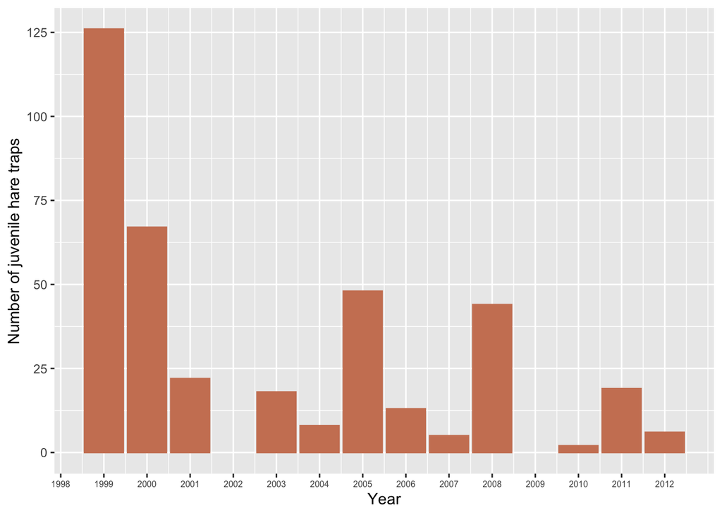

**Figure 1.** Total number of juvenile snowshoe hare trappings in each year from 1998-2012 at the Bonanza Creek Experimental Forest Long Term Ecological Research (LTER) network site. Data: Kielland et al. (2017).

The minimum count of juvenile hare trappings is 2 traps, while the maximum is 126 traps. The mean annual number of juvenile hare traps is 31.5 traps and the median is 18.5 traps. There doesn’t appears to be any significant trends, but it it can be concluded that the highest number of annual hare trappings occurred before 2001 and decreased through time, with the exception of years 2005 and 2008. It should also be noted that there was no juvenile hare trap observations for 1998, 2002, and 2009. Absolute counts vs counts that are impacted by effort could provide us with very different data. If we include effort (number of days and number of traps in the study each year) it is possible that effort has been the same or similar between 1998 and 2012, but there is less juvenile hares around to trap. There is a different number of observations for each year, this could be a useful way to quantify effort moving forward in order to standardize the data for future analysis.

### B. Juvenile Snowshoe hare weights comparison by sex and grid

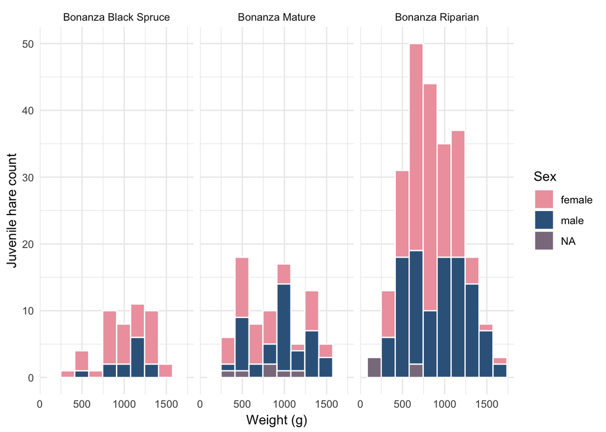

**Figure 2.** Weight observations (grams) for juvenile hares of different sexes: Pink(female), blue(male), and purple(NA) at each of the following locations: Bonanza Black Spruce, Bonanza Mature, and Bonanza Riparian at Bonanza Creek Experimental Forest LTER network site. Data: Kielland et al. (2017).

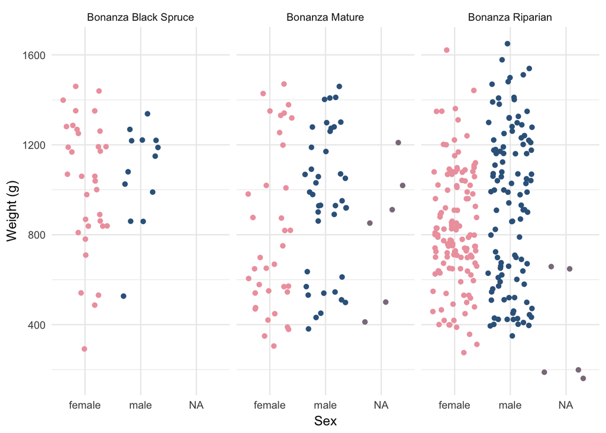

**Figure 3**. Weight observations (grams) for juvenile hares of different sexes (female, male, and NA). Pink(female), blue(male), and purple(NA) indicate individual observations for weight (grams) of juvenile hares at three different locations (Bonanza Black Spruce, Bonanza Mature, and Bonanza Riparian) at Bonanza Creek Experimental Forest LTER network site.Data: Kielland et al. (2017).

For data visualization, both a histogram graph (Figure 2.) and a jitter plot (Figure 3.) is provided. On average, there are the most observations of juvenile hare trappings at grid Bonanza Riparian and the least at Bonanza Black spruce. Also, on average male and female juvenile hares have similar weight distribution at each of the three sites. Furthermore, according to Figure 2., the distribution for female juvenile hares appear to be normally distributed and the male juvenile hare distribution appears to vary more or possibly be skewed. However, further analysis is needed to determine if this data is normally distributed.The NA juvenile hares at each site may have not have been categorized by their sex do to sampling errors.

### C. Juvenile weight comparison between male & female snowshoe hares

Table 1.Mean, median, sd, and sample size values of juvenile hare weight in grams (g) of both females and males at Bonanza Creek LTER. Data: Kielland et al. (2017).

| Sex | Mean weight (g) | Median weight (g) | SD of weight (g) | Sample size |
| --- | --- | --- | --- | --- |
| female | 855.39 | 825 | 292.25 | 200 |
| male | 945.86 | 990 | 333.22 | 163 |
| NA | 614.55 | 650 | 357.59 | 15 |

On average, male juvenile hares are greater in weight than females with the mean for males being 945.86 g $\pm$ 333.22 g and mean for females being 855.39 g $\pm$ 292.25 g. The absolute difference means is 90.47 mm (a 10.05% difference), The difference in means is significant (Welch’s two-sample t-test: t(325.02) = -2.71, p < 0.01), and the effect size is small (Cohen’s *d* = -0.29). Getting a p value of 0.007 means there is a 0.7 % chance of getting means at least as different as the means found here if they were drawn from populations with the same mean. This means that we would reject the null hypothesis that the means are the same.

### D. Relationship between juvenile weight & hind foot length.

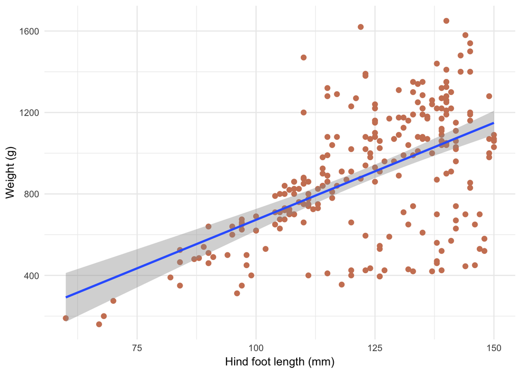

**Figure 4.** Relationship between weight (g) & hind foot length (mm) in juvenile Snowshoe hares. Points are individual juvenile hares. Linear model summary: $\beta$ = 9.52 g mm<sup>-1</sup>, p < 0.001, R<sup>2</sup> = 0.3, (Pearson’s *r* = 0.55. Data: Kielland et al. (2017).

Simple linear regression was used to explore the relationship between juvenile hare weight (g) and hind foot length (mm) across all sex and sites. Simple linear regression revealed that high foot length (mm) significantly predicts weight (g) (p < 0.001). R<sup>2</sup> = 0.3 tells us that 30 % of the variance in the dependent variable (weight) is predictable from the independent variable (hind foot length). This means that 70 % of the variance is not explained by the model. This indicates that some important variables might be missing such as sex and/or the site at which the hare was at. An average slope of $\beta$ = 9.52 g mm<sup>-1</sup> indicates that for each one millimeter increase in hind foot length we expect an average increase in body weight of 9.52 g). Given that the diagnostic plots (not included) explored previously revealed somewhat normally distributed and homoscedastic residuals, linear regression can be used to explore this data. hind foot length and weight are moderately strong, significantly, positively correlated (Pearson’s *r* = 0.55, p < 0.001).

## Summary

- The most snowshoe hare trappings were recorded in 1999. This does not include effort and effort would be useful for future analysis
- Weight distributions between male and female hares are somewhat similar and do not vary much between sites. But, overall male hares are larger in regards to weight (g) with a mean of 945.86 and female mean weight of 855.39.
- Juvenile hare body weight (g) increases with hind foot length (mm) in the simple linear regression model. The model indicates that for each one millimeter increase in hind foot length we expect an average increase in body weight of 9.52 g. However, this interpretation should be made with caution because important variables such as sex and site was not included

## Future Analysis

- Quantify and include effort in exploration of annual juvenile hare trappings
- Conduct multiple linear regression to predict the outcome of juvenile hare body weight (g) with explanatory variables being sex, site, and hind foot length (mm)
- It would also be interesting to see if a similar relationship exists among adult snowshoe hares

## Citations

Kielland, K., F.S. Chapin, R.W. Ruess, and Bonanza Creek LTER. 2017. Snowshoe hare physical data in Bonanza Creek Experimental Forest: 1999-Present ver 22. Environmental Data Initiative. https://doi.org/10.6073/pasta/03dce4856d79b91557d8e6ce2cbcdc14